# CSDA1050 Capstone Project Sprint2

Eugene Yong Geun Park

2019-08-13

# Background

### Continuing from Sprint1, predictive models are being built using refined dataset.

# ML Modelling

### Applying various ML techniques to create models which can discover factors that influence employee retention. Starting with classification models as employees are to be classified as Active, Quit, and Terminated status. In addition, other methods and models will be applied as necessary to discover other insights.

```r
library(dplyr)
#importing the original file. Feature engineering that was perfored in Sprint1 is replicated for Sprint2 modelling.
hr<-read.csv("~/Desktop/CSDA-1050F18S1/eugenepark/CSDA1050HR.csv")
hdate <- as.character(hr$Hire)
tdate <- as.character(hr$Termination)
bdate <- as.character(hr$DOB)
hr$hdate = as.Date(hdate, format="%Y%m%d")
hr$tdate = as.Date(tdate, format="%Y%m%d")
hr$bdate = as.Date(bdate, format="%Y%m%d")
hr$hireage <- as.integer(round((hr$hdate-hr$bdate)/365, digit=0))
hr$termage <- as.integer(round((hr$tdate-hr$bdate)/365, digit=0))
hr$current <-as.Date(Sys.Date())
hr$tenure <- ifelse(is.na(hr$termage), as.integer(round((hr$current-hr$hdate)/365, digit=0))
                    ,as.integer(round((hr$tdate-hr$hdate)/365, digit=0)))
```

## Decision Tree 1:

## Starting it off with a Decision Tree model which incorporates all variables from Sprint1. Prior to creating a model, I am subsetting the dataset into Train(80%) & Test(20%). For now, I am fitting in all variables that were explored in Sprint1.

```r
library(caTools)
#Employees' whose TermType is blank, filling them in as "Active" so modelling can go smoothly.
levels(hr$TermType)[1] <-"Active"
hrmodel <- select(hr, C.LEVEL, Team, Job.Level, Team, Raise, Education, DistToWork, TermType, hireage, termage, tenure)
str(hrmodel)
```

```
## 'data.frame':    127 obs. of  10 variables:
##  $ C.LEVEL   : Factor w/ 6 levels "C1","C2","C3",..: 3 3 2 3 2 1 3 3 2 2 ...
##  $ Team      : Factor w/ 5 levels "Account Services",..: 3 3 1 1 5 1 4 5 3 3 ...
##  $ Job.Level : Factor w/ 5 levels "Associate","Manager",..: 5 5 5 5 1 1 5 5 1 1 ...
##  $ Raise     : Factor w/ 5 levels " -   ","1","2",..: 2 3 2 1 3 3 1 2 1 1 ...
##  $ Education : Factor w/ 4 levels "Bachelors Degree",..: 1 1 1 1 1 2 1 1 1 1 ...
##  $ DistToWork: num  15 40 25 20 13.3 24.5 23 45.3 8 5.2 ...
##  $ TermType  : Factor w/ 3 levels "Active","Quit",..: 2 2 2 2 2 2 2 2 2 2 ...
##  $ hireage   : int  32 41 27 34 26 28 28 39 32 29 ...
##  $ termage   : int  37 45 32 38 33 31 29 42 33 30 ...
##  $ tenure    : int  5 4 5 4 6 3 1 3 0 1 ...
```

```r
set.seed(100)
sample <- sample.split(hrmodel, SplitRatio = 0.8)
train <- subset(hrmodel, sample==TRUE)
test <- subset(hrmodel, sample==FALSE)
```

```r
prop.table((table(train$TermType)))
```

```
##
##     Active       Quit Terminated
##  0.1287129  0.6138614  0.2574257
```

```r
prop.table((table(test$TermType)))
```

```
##
##     Active       Quit Terminated
##  0.1538462  0.6153846  0.2307692
```

### Noting that this tree isn’t classifying any of “Active” employees here.

```r
library(rpart)
```

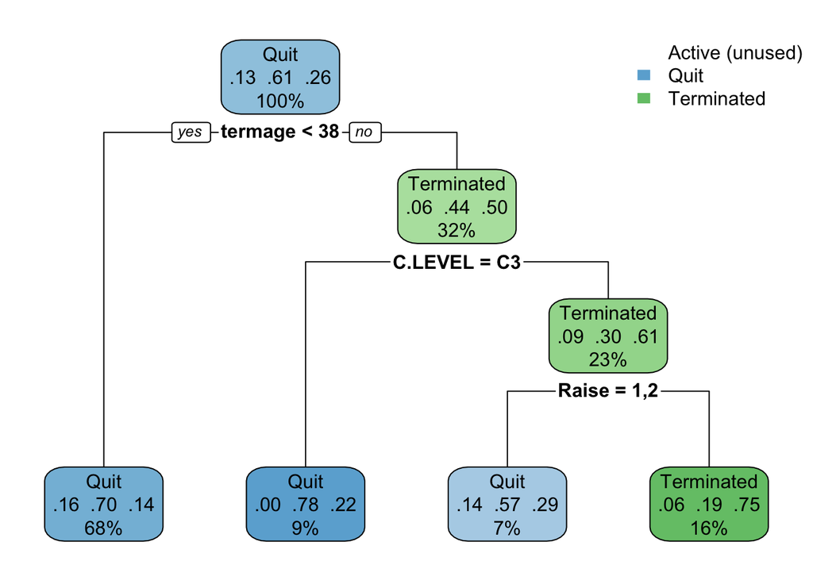

```r
library(tree)
library(rpart.plot)
fit <- rpart(TermType~., data=train)
rpart.plot(fit)
```

```r
summary(fit)
```

```
## Call:
## rpart(formula = TermType ~ ., data = train)
##   n= 101
##
##           CP nsplit rel error   xerror      xstd
## 1 0.08974359      0 1.0000000 1.000000 0.1254593
## 2 0.05128205      2 0.8205128 1.102564 0.1274157
## 3 0.01000000      3 0.7692308 1.025641 0.1260287
##
## Variable importance
##    termage    hireage    C.LEVEL      Raise  Job.Level DistToWork
##         26         24         22          9          8          5
##       Team     tenure
##          5          1
##
## Node number 1: 101 observations,    complexity param=0.08974359
##   predicted class=Quit        expected loss=0.3861386  P(node) =1
##     class counts:    13    62    26
##    probabilities: 0.129 0.614 0.257
##   left son=2 (69 obs) right son=3 (32 obs)
##   Primary splits:
##       termage   < 37.5  to the left,  improve=5.151306, (13 missing)
##       hireage   < 31.5  to the left,  improve=4.885526, (0 missing)
##       Job.Level splits as  LRRRL,     improve=4.404344, (0 missing)
##       C.LEVEL   splits as  LLLRRR,    improve=3.429813, (0 missing)
##       Education splits as  RLRR,      improve=2.807078, (0 missing)
##   Surrogate splits:
##       hireage    < 34.5  to the left,  agree=0.955, adj=0.867, (13 split)
##       C.LEVEL    splits as  LLLRRR,    agree=0.761, adj=0.300, (0 split)
##       Job.Level  splits as  LLRRL,     agree=0.761, adj=0.300, (0 split)
##       Team       splits as  LRLLR,     agree=0.727, adj=0.200, (0 split)
##       DistToWork < 28.45 to the left,  agree=0.693, adj=0.100, (0 split)
##
## Node number 2: 69 observations
##   predicted class=Quit        expected loss=0.3043478  P(node) =0.6831683
##     class counts:    11    48    10
##    probabilities: 0.159 0.696 0.145
##
## Node number 3: 32 observations,    complexity param=0.08974359
##   predicted class=Terminated  expected loss=0.5  P(node) =0.3168317
```

[output cut: 27 more lines]

```
##       Team       splits as  LLRRL,     improve=0.2453416, (0 missing)
##   Surrogate splits:
##       C.LEVEL splits as  LR-RRR,    agree=0.739, adj=0.143, (0 split)
##       hireage < 35.5  to the left,  agree=0.739, adj=0.143, (0 split)
##       tenure  < 2.5   to the right, agree=0.739, adj=0.143, (0 split)
##
## Node number 14: 7 observations
##   predicted class=Quit        expected loss=0.4285714  P(node) =0.06930693
##     class counts:     1     4     2
##    probabilities: 0.143 0.571 0.286
##
## Node number 15: 16 observations
##   predicted class=Terminated  expected loss=0.25  P(node) =0.1584158
##     class counts:     1     3    12
##    probabilities: 0.062 0.188 0.750
```

### Checking the overall accuracy of the model. 53% can not be considered reliable.

```r
library(caret)
predict <- predict(fit, test, type='class')
confusionMatrix(predict, test$TermType)
```

```
## Confusion Matrix and Statistics
##
##             Reference
## Prediction   Active Quit Terminated
##   Active          0    0          0
##   Quit            3   14          6
##   Terminated      1    2          0
##
## Overall Statistics
##
##                Accuracy : 0.5385
##                  95% CI : (0.3337, 0.7341)
##     No Information Rate : 0.6154
##     P-Value [Acc > NIR] : 0.8432
##
##                   Kappa : -0.0759
##
##  Mcnemar's Test P-Value : 0.1116
##
## Statistics by Class:
##
##                      Class: Active Class: Quit Class: Terminated
## Sensitivity                 0.0000      0.8750            0.0000
## Specificity                 1.0000      0.1000            0.8500
## Pos Pred Value                 NaN      0.6087            0.0000
## Neg Pred Value              0.8462      0.3333            0.7391
## Prevalence                  0.1538      0.6154            0.2308
## Detection Rate              0.0000      0.5385            0.0000
## Detection Prevalence        0.0000      0.8846            0.1154
## Balanced Accuracy           0.5000      0.4875            0.4250
```

## Decision Tree 2:

### Starting to explore variables that seemed more relevant than previous attempt. As a result, visually, this tree has been able to classify all three statuses of employees: “Active”, “Quit”, and “Terminated”, while previous model failed does not. However, overall accuracy and reliability have worsened (46%).

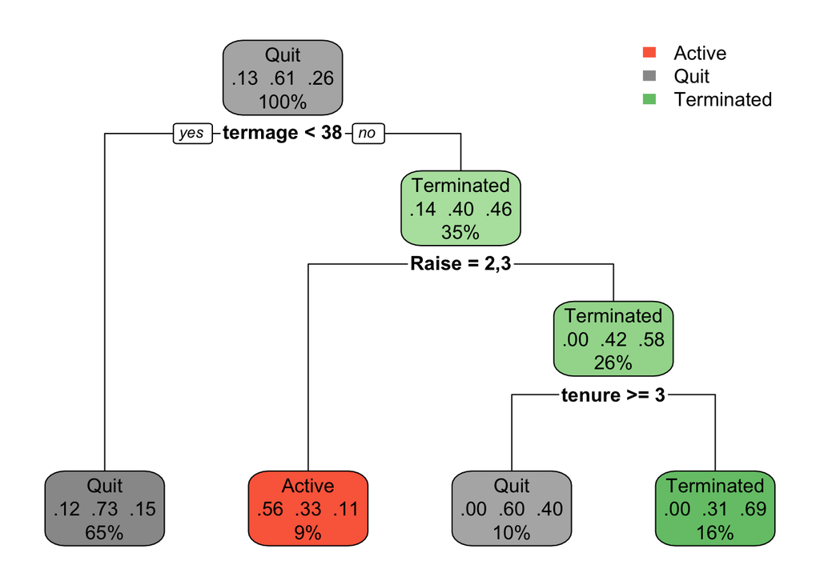

```r
#Chosen variables are tenure, Raise and termage.
hrmodel2 <- select(hr, TermType, tenure, Raise, termage)
set.seed(102)
sample2 <- sample.split(hrmodel2, SplitRatio = 0.8)
train2 <- subset(hrmodel2, sample==TRUE)
test2 <- subset(hrmodel2, sample==FALSE)
fit2 <- rpart(TermType~.,data=train2)
rpart.plot(fit2)
```

```r
predict2 <- predict(fit2, test2, type='class')
confusionMatrix(predict2, test2$TermType)
```

```
## Confusion Matrix and Statistics
##
##             Reference
## Prediction   Active Quit Terminated
##   Active          0    0          0
##   Quit            4   12          6
##   Terminated      0    4          0
##
## Overall Statistics
##
##                Accuracy : 0.4615
##                  95% CI : (0.2659, 0.6663)
##     No Information Rate : 0.6154
##     P-Value [Acc > NIR] : 0.9635
##
##                   Kappa : -0.2133
##
##  Mcnemar's Test P-Value : NA
##
## Statistics by Class:
##
##                      Class: Active Class: Quit Class: Terminated
## Sensitivity                 0.0000      0.7500            0.0000
## Specificity                 1.0000      0.0000            0.8000
## Pos Pred Value                 NaN      0.5455            0.0000
## Neg Pred Value              0.8462      0.0000            0.7273
## Prevalence                  0.1538      0.6154            0.2308
## Detection Rate              0.0000      0.4615            0.0000
## Detection Prevalence        0.0000      0.8462            0.1538
## Balanced Accuracy           0.5000      0.3750            0.4000
```

## Decision Tree 3:

### After numerous attempts of combining what seemed to be significant factors from Data Exploration, below tree is a model that gives higher accuracy (57%) than previous ones. Again, this can not be considered as a reliable model but it shares some insight.

### Associate & Supervisor are relatively junior positions and the organization is not doing a good job retaining them as majority of them leaves voluntarily. On the other hand, employees who are not “associate” or “supervisor”" can be considered as more senior positions and they face more frequent cases of termination.

### When drilled down deeper, among Associates & Supervisors, employees in Account, Corporate, Creative and Planning departments, tend to leave more voluntarily, which leaves Production department that has less portion of quitting. This makes sense because first mentioned 4 divisions are more Advertising specific roles which are sought after and more actively recruited. Production department’s role and scope do not tend to change from one company to another, which leads to less active recruitment.

### And for senior positions, the tree indicates that tenure is one of significant factors, which also is logical. In company’s perspective, Senior position is a bigger investment. Their value and/or ROI is more closely monitored and retention decisions will have to be made timely for financial reasons.

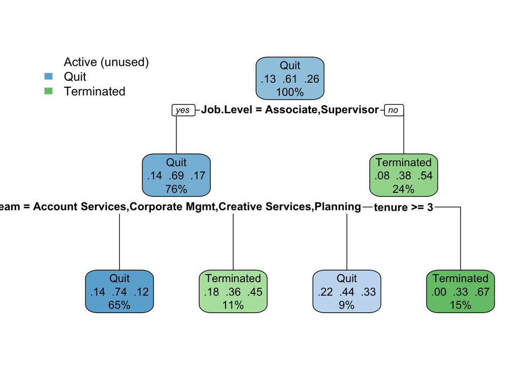

```r
hrmodel3 <- select(hr, TermType, tenure, Team, Job.Level)
set.seed(104)
sample3 <- sample.split(hrmodel3, SplitRatio = 0.8)
train3 <- subset(hrmodel3, sample==TRUE)
test3 <- subset(hrmodel3, sample==FALSE)
fit3 <- rpart(TermType~.,data=train3)
rpart.plot(fit3)
```

```r
predict3 <- predict(fit3, test3, type='class')
confusionMatrix(predict3, test3$TermType)
```

```
## Confusion Matrix and Statistics
##
##             Reference
## Prediction   Active Quit Terminated
##   Active          0    0          0
##   Quit            4   13          4
##   Terminated      0    3          2
##
## Overall Statistics
##
##                Accuracy : 0.5769
##                  95% CI : (0.3692, 0.7665)
##     No Information Rate : 0.6154
##     P-Value [Acc > NIR] : 0.7302
##
##                   Kappa : 0.0774
##
##  Mcnemar's Test P-Value : NA
##
## Statistics by Class:
##
##                      Class: Active Class: Quit Class: Terminated
## Sensitivity                 0.0000      0.8125           0.33333
## Specificity                 1.0000      0.2000           0.85000
## Pos Pred Value                 NaN      0.6190           0.40000
## Neg Pred Value              0.8462      0.4000           0.80952
## Prevalence                  0.1538      0.6154           0.23077
## Detection Rate              0.0000      0.5000           0.07692
## Detection Prevalence        0.0000      0.8077           0.19231
## Balanced Accuracy           0.5000      0.5062           0.59167
```

## Random Forest 1:

### Trying a Random Forest model, using the same dataset(variables) from Decision Tree 3 as it had given the highest accuracy so far. Unfortunately, the result does not seem to provide any improvement in accuracy.

```r
library(randomForest)
set.seed(47)
rfmodel3 <- randomForest(TermType ~., data=train3, proximity=TRUE)
rfmodel3
```

```
##
## Call:
##  randomForest(formula = TermType ~ ., data = train3, proximity = TRUE)
##                Type of random forest: classification
##                      Number of trees: 500
## No. of variables tried at each split: 1
##
##         OOB estimate of  error rate: 40.59%
## Confusion matrix:
##            Active Quit Terminated class.error
## Active          0   11          2   1.0000000
## Quit            1   55          6   0.1129032
## Terminated      0   21          5   0.8076923
```

```r
rfpredict3 <- predict(rfmodel3, test3, type='class')
confusionMatrix(rfpredict3, test3$TermType)
```

```
## Confusion Matrix and Statistics
##
##             Reference
## Prediction   Active Quit Terminated
##   Active          0    1          0
##   Quit            4   14          5
##   Terminated      0    1          1
##
## Overall Statistics
##
##                Accuracy : 0.5769
##                  95% CI : (0.3692, 0.7665)
##     No Information Rate : 0.6154
##     P-Value [Acc > NIR] : 0.7302
##
##                   Kappa : 0.0205
##
##  Mcnemar's Test P-Value : NA
##
## Statistics by Class:
##
##                      Class: Active Class: Quit Class: Terminated
## Sensitivity                0.00000      0.8750           0.16667
## Specificity                0.95455      0.1000           0.95000
## Pos Pred Value             0.00000      0.6087           0.50000
## Neg Pred Value             0.84000      0.3333           0.79167
## Prevalence                 0.15385      0.6154           0.23077
## Detection Rate             0.00000      0.5385           0.03846
## Detection Prevalence       0.03846      0.8846           0.07692
## Balanced Accuracy          0.47727      0.4875           0.55833
```

## Decision Tree 4:

### Although I start to realize that size of my dataset sets limit to building a reliable model, I start to wonder if classifying “Active” employee is actually adding value to this analysis. Perhaps, the analysis should focus on characterstics of “Quit” employees and “Terminated” employees. Then the discovery can be applied to “Active” employees for operational action plan. In addition, removing a classification with smallest data size and least accurary (Again, “Active” status) from confusion matrix might reveal how this model can truly perform classifying “Quit” and “Terminated” status.

### This is the same dataset used in very first Decision Tree1 and by excluding “Active” status from the dataset, the accuracy has improved from 53% to 63%.

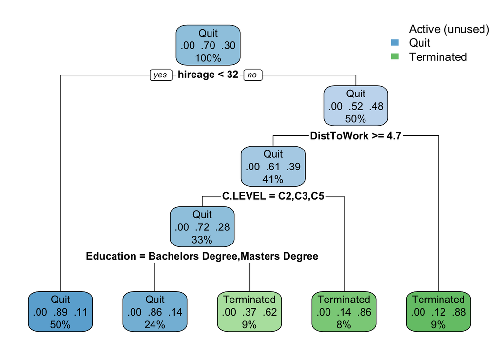

```r
newhrmodel<-hrmodel[!(hrmodel$TermType=="Active"),]
set.seed(111)
newsample <- sample.split(newhrmodel, SplitRatio = 0.8)
newtrain <- subset(newhrmodel, sample==TRUE)
newtest <- subset(newhrmodel, sample==FALSE)
newfit <- rpart(TermType~.,data=newtrain)
rpart.plot(newfit)
```

```r
newpredict <- predict(newfit, newtest, type='class')
confusionMatrix(newpredict, newtest$TermType)
```

```
## Confusion Matrix and Statistics
##
##             Reference
## Prediction   Active Quit Terminated
##   Active          0    0          0
##   Quit            0   12          4
##   Terminated      0    4          2
##
## Overall Statistics
##
##                Accuracy : 0.6364
##                  95% CI : (0.4066, 0.828)
##     No Information Rate : 0.7273
##     P-Value [Acc > NIR] : 0.8822
##
##                   Kappa : 0.0833
##
##  Mcnemar's Test P-Value : NA
##
## Statistics by Class:
##
##                      Class: Active Class: Quit Class: Terminated
## Sensitivity                     NA      0.7500           0.33333
## Specificity                      1      0.3333           0.75000
## Pos Pred Value                  NA      0.7500           0.33333
## Neg Pred Value                  NA      0.3333           0.75000
## Prevalence                       0      0.7273           0.27273
## Detection Rate                   0      0.5455           0.09091
## Detection Prevalence             0      0.7273           0.27273
## Balanced Accuracy               NA      0.5417           0.54167
```

## Decision Tree 5:

### This now tests the Decision tree3 which had 57% accuracy. And excluding “Active” status has improved the model to 68%.

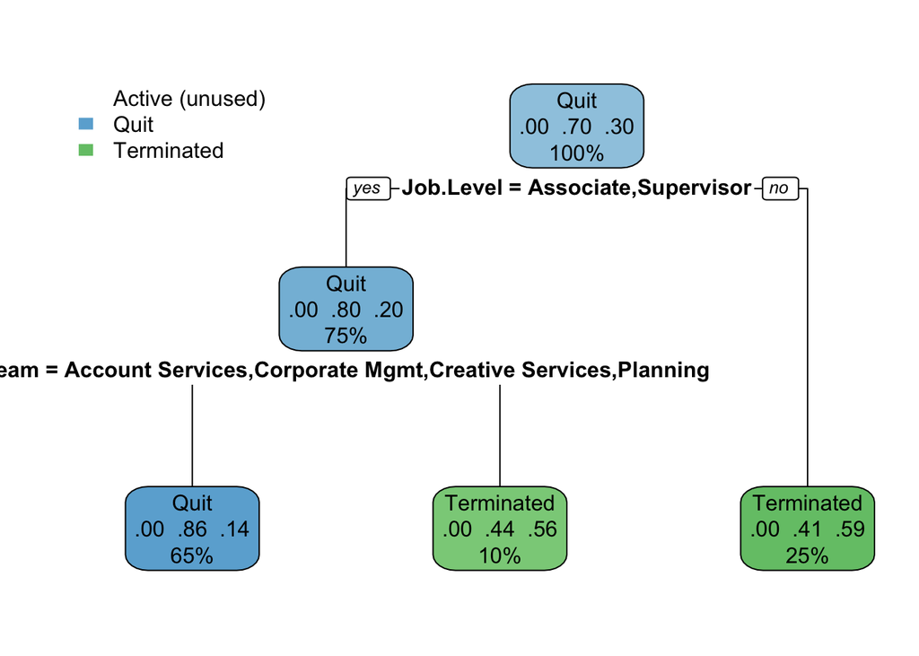

```r
newhrmodel3<-hrmodel3[!(hrmodel3$TermType=="Active"),]
set.seed(113)
newsample3 <- sample.split(newhrmodel3, SplitRatio = 0.8)
newtrain3 <- subset(newhrmodel3, sample==TRUE)
newtest3 <- subset(newhrmodel3, sample==FALSE)
newfit3 <- rpart(TermType~.,data=newtrain3)
rpart.plot(newfit3)
```

```r
newpredict3 <- predict(newfit3, newtest3, type='class')
confusionMatrix(newpredict3, newtest3$TermType)
```

```
## Confusion Matrix and Statistics
##
##             Reference
## Prediction   Active Quit Terminated
##   Active          0    0          0
##   Quit            0   12          3
##   Terminated      0    4          3
##
## Overall Statistics
##
##                Accuracy : 0.6818
##                  95% CI : (0.4513, 0.8614)
##     No Information Rate : 0.7273
##     P-Value [Acc > NIR] : 0.7689
##
##                   Kappa : 0.2376
##
##  Mcnemar's Test P-Value : NA
##
## Statistics by Class:
##
##                      Class: Active Class: Quit Class: Terminated
## Sensitivity                     NA      0.7500            0.5000
## Specificity                      1      0.5000            0.7500
## Pos Pred Value                  NA      0.8000            0.4286
## Neg Pred Value                  NA      0.4286            0.8000
## Prevalence                       0      0.7273            0.2727
## Detection Rate                   0      0.5455            0.1364
## Detection Prevalence             0      0.6818            0.3182
## Balanced Accuracy               NA      0.6250            0.6250
```

### Although there is a small improvement in accuracy in Decision Tree models, it is concluded that a reliable classification model can not be built based on this dataset. I have decided to look into correlation between hiring data and annual revenue, using linear regression.